# Risk Factor Analysis

## Outcome Variable

**Outcome Variable:** dead624

## Predictor Variables

**Intervention Variable:** pers_wasted024

**Adjustment Set:**

- sex
- arm
- brthmon
- vagbrth
- hhwealth_quart
- W_mage
- W_mhtcm
- W_mwtkg
- W_mbmi
- W_meducyrs
- W_feducyrs
- W_nrooms
- W_parity
- impsan
- safeh20
- delta_vagbrth
- delta_hhwealth_quart
- delta_W_mage
- delta_W_mhtcm
- delta_W_mwtkg
- delta_W_mbmi
- delta_W_meducyrs
- delta_W_feducyrs
- delta_W_nrooms
- delta_W_parity
- delta_impsan
- delta_safeh20

## Stratifying Variables

The analysis was stratified on these variable(s):

- studyid
- country

## Data Summary

| studyid | country | pers_wasted024 | dead624 | n_cell | n | outcome_variable |
| --- | --- | --- | --- | --- | --- | --- |
| Burkina Faso Zn | BURKINA FASO | 0 | 0 | 6023 | 7164 | dead624 |
| Burkina Faso Zn | BURKINA FASO | 0 | 1 | 25 | 7164 | dead624 |
| Burkina Faso Zn | BURKINA FASO | 1 | 0 | 1102 | 7164 | dead624 |
| Burkina Faso Zn | BURKINA FASO | 1 | 1 | 14 | 7164 | dead624 |
| EE | PAKISTAN | 0 | 0 | 338 | 375 | dead624 |
| EE | PAKISTAN | 0 | 1 | 4 | 375 | dead624 |
| EE | PAKISTAN | 1 | 0 | 33 | 375 | dead624 |
| EE | PAKISTAN | 1 | 1 | 0 | 375 | dead624 |
| GMS-Nepal | NEPAL | 0 | 0 | 511 | 592 | dead624 |
| GMS-Nepal | NEPAL | 0 | 1 | 1 | 592 | dead624 |
| GMS-Nepal | NEPAL | 1 | 0 | 79 | 592 | dead624 |
| GMS-Nepal | NEPAL | 1 | 1 | 1 | 592 | dead624 |
| iLiNS-DOSE | MALAWI | 0 | 0 | 1690 | 1874 | dead624 |
| iLiNS-DOSE | MALAWI | 0 | 1 | 119 | 1874 | dead624 |
| iLiNS-DOSE | MALAWI | 1 | 0 | 57 | 1874 | dead624 |
| iLiNS-DOSE | MALAWI | 1 | 1 | 8 | 1874 | dead624 |
| iLiNS-DYAD-M | MALAWI | 0 | 0 | 1115 | 1161 | dead624 |
| iLiNS-DYAD-M | MALAWI | 0 | 1 | 21 | 1161 | dead624 |
| iLiNS-DYAD-M | MALAWI | 1 | 0 | 22 | 1161 | dead624 |
| iLiNS-DYAD-M | MALAWI | 1 | 1 | 3 | 1161 | dead624 |
| JiVitA-3 | BANGLADESH | 0 | 0 | 19478 | 21023 | dead624 |
| JiVitA-3 | BANGLADESH | 0 | 1 | 221 | 21023 | dead624 |
| JiVitA-3 | BANGLADESH | 1 | 0 | 1280 | 21023 | dead624 |
| JiVitA-3 | BANGLADESH | 1 | 1 | 44 | 21023 | dead624 |
| JiVitA-4 | BANGLADESH | 0 | 0 | 4948 | 5433 | dead624 |
| JiVitA-4 | BANGLADESH | 0 | 1 | 39 | 5433 | dead624 |
| JiVitA-4 | BANGLADESH | 1 | 0 | 436 | 5433 | dead624 |
| JiVitA-4 | BANGLADESH | 1 | 1 | 10 | 5433 | dead624 |
| Keneba | GAMBIA | 0 | 0 | 2523 | 2752 | dead624 |
| Keneba | GAMBIA | 0 | 1 | 38 | 2752 | dead624 |
| Keneba | GAMBIA | 1 | 0 | 185 | 2752 | dead624 |
| Keneba | GAMBIA | 1 | 1 | 6 | 2752 | dead624 |
| MAL-ED | BANGLADESH | 0 | 0 | 227 | 240 | dead624 |
| MAL-ED | BANGLADESH | 0 | 1 | 0 | 240 | dead624 |
| MAL-ED | BANGLADESH | 1 | 0 | 13 | 240 | dead624 |
| MAL-ED | BANGLADESH | 1 | 1 | 0 | 240 | dead624 |
| MAL-ED | INDIA | 0 | 0 | 215 | 235 | dead624 |
| MAL-ED | INDIA | 0 | 1 | 0 | 235 | dead624 |
| MAL-ED | INDIA | 1 | 0 | 20 | 235 | dead624 |
| MAL-ED | INDIA | 1 | 1 | 0 | 235 | dead624 |
| MAL-ED | PERU | 0 | 0 | 271 | 273 | dead624 |
| MAL-ED | PERU | 0 | 1 | 1 | 273 | dead624 |
| MAL-ED | PERU | 1 | 0 | 1 | 273 | dead624 |
| MAL-ED | PERU | 1 | 1 | 0 | 273 | dead624 |
| MAL-ED | SOUTH AFRICA | 0 | 0 | 259 | 261 | dead624 |
| MAL-ED | SOUTH AFRICA | 0 | 1 | 0 | 261 | dead624 |
| MAL-ED | SOUTH AFRICA | 1 | 0 | 2 | 261 | dead624 |
| MAL-ED | SOUTH AFRICA | 1 | 1 | 0 | 261 | dead624 |
| MAL-ED | TANZANIA, UNITED REPUBLIC OF | 0 | 0 | 245 | 245 | dead624 |
| MAL-ED | TANZANIA, UNITED REPUBLIC OF | 0 | 1 | 0 | 245 | dead624 |
| MAL-ED | TANZANIA, UNITED REPUBLIC OF | 1 | 0 | 0 | 245 | dead624 |
| MAL-ED | TANZANIA, UNITED REPUBLIC OF | 1 | 1 | 0 | 245 | dead624 |
| PROVIDE | BANGLADESH | 0 | 0 | 601 | 617 | dead624 |
| PROVIDE | BANGLADESH | 0 | 1 | 2 | 617 | dead624 |
| PROVIDE | BANGLADESH | 1 | 0 | 14 | 617 | dead624 |
| PROVIDE | BANGLADESH | 1 | 1 | 0 | 617 | dead624 |
| SAS-CompFeed | INDIA | 0 | 0 | 1266 | 1389 | dead624 |
| SAS-CompFeed | INDIA | 0 | 1 | 4 | 1389 | dead624 |
| SAS-CompFeed | INDIA | 1 | 0 | 111 | 1389 | dead624 |
| SAS-CompFeed | INDIA | 1 | 1 | 8 | 1389 | dead624 |
| SAS-FoodSuppl | INDIA | 0 | 0 | 327 | 402 | dead624 |
| SAS-FoodSuppl | INDIA | 0 | 1 | 1 | 402 | dead624 |
| SAS-FoodSuppl | INDIA | 1 | 0 | 71 | 402 | dead624 |
| SAS-FoodSuppl | INDIA | 1 | 1 | 3 | 402 | dead624 |
| TanzaniaChild2 | TANZANIA, UNITED REPUBLIC OF | 0 | 0 | 2038 | 2096 | dead624 |
| TanzaniaChild2 | TANZANIA, UNITED REPUBLIC OF | 0 | 1 | 0 | 2096 | dead624 |
| TanzaniaChild2 | TANZANIA, UNITED REPUBLIC OF | 1 | 0 | 58 | 2096 | dead624 |
| TanzaniaChild2 | TANZANIA, UNITED REPUBLIC OF | 1 | 1 | 0 | 2096 | dead624 |
| VITAMIN-A | INDIA | 0 | 0 | 3029 | 3615 | dead624 |
| VITAMIN-A | INDIA | 0 | 1 | 13 | 3615 | dead624 |
| VITAMIN-A | INDIA | 1 | 0 | 555 | 3615 | dead624 |
| VITAMIN-A | INDIA | 1 | 1 | 18 | 3615 | dead624 |
| ZVITAMBO | ZIMBABWE | 0 | 0 | 11000 | 11694 | dead624 |
| ZVITAMBO | ZIMBABWE | 0 | 1 | 340 | 11694 | dead624 |
| ZVITAMBO | ZIMBABWE | 1 | 0 | 291 | 11694 | dead624 |
| ZVITAMBO | ZIMBABWE | 1 | 1 | 63 | 11694 | dead624 |

The following strata were considered:

- studyid: Burkina Faso Zn, country: BURKINA FASO
- studyid: EE, country: PAKISTAN
- studyid: GMS-Nepal, country: NEPAL
- studyid: iLiNS-DOSE, country: MALAWI
- studyid: iLiNS-DYAD-M, country: MALAWI
- studyid: JiVitA-3, country: BANGLADESH
- studyid: JiVitA-4, country: BANGLADESH
- studyid: Keneba, country: GAMBIA
- studyid: MAL-ED, country: BANGLADESH
- studyid: MAL-ED, country: INDIA
- studyid: MAL-ED, country: PERU
- studyid: MAL-ED, country: SOUTH AFRICA
- studyid: MAL-ED, country: TANZANIA, UNITED REPUBLIC OF
- studyid: PROVIDE, country: BANGLADESH
- studyid: SAS-CompFeed, country: INDIA
- studyid: SAS-FoodSuppl, country: INDIA
- studyid: TanzaniaChild2, country: TANZANIA, UNITED REPUBLIC OF
- studyid: VITAMIN-A, country: INDIA
- studyid: ZVITAMBO, country: ZIMBABWE

### Dropped Strata

Some strata were dropped due to rare outcomes:

- studyid: EE, country: PAKISTAN
- studyid: GMS-Nepal, country: NEPAL
- studyid: iLiNS-DYAD-M, country: MALAWI
- studyid: MAL-ED, country: BANGLADESH
- studyid: MAL-ED, country: INDIA
- studyid: MAL-ED, country: PERU
- studyid: MAL-ED, country: SOUTH AFRICA
- studyid: MAL-ED, country: TANZANIA, UNITED REPUBLIC OF
- studyid: PROVIDE, country: BANGLADESH
- studyid: SAS-CompFeed, country: INDIA
- studyid: SAS-FoodSuppl, country: INDIA
- studyid: TanzaniaChild2, country: TANZANIA, UNITED REPUBLIC OF

## Methods Detail

We’re interested in the causal parameters $E[Y_a]$ for all values of $a \in \mathcal{A}$. These parameters represent the mean outcome if, possibly contrary to fact, we intervened to set all units to have $A=a$. Under the randomization and positivity assumptions, these are identified by the statistical parameters $\psi_a=E_W[E_{Y|A,W}(Y|A=a,W)]$. In addition, we’re interested in the mean of $Y$, $E[Y]$ under no intervention (the observed mean). We will estimate these parameters by using SuperLearner to fit the relevant likelihood factors – $E_{Y|A,W}(Y|A=a,W)$ and $p(A=a|W)$, and then updating our likelihood fit using a joint TMLE.

For unadjusted analyses ($W=\{\}$), initial likelihoods were estimated using Lrnr_glm to estimate the simple $E(Y|A)$ and Lrnr_mean to estimate $p(A)$. For adjusted analyses, a small library containing Lrnr_glmnet, Lrnr_xgboost, and Lrnr_mean was used.

Having estimated these parameters, we will then use the delta method to estimate relative risks and attributable risks relative to a prespecified baseline level of $A$.

[output not shown]

# Results Detail

## Results Plots

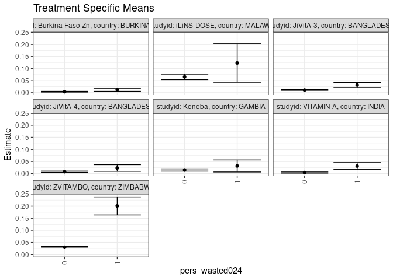

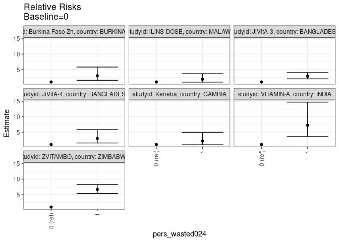

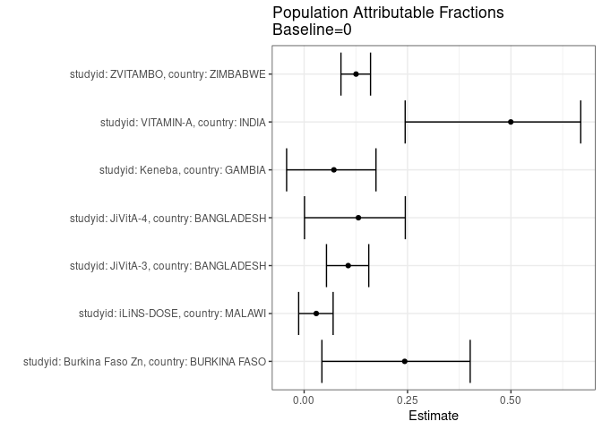

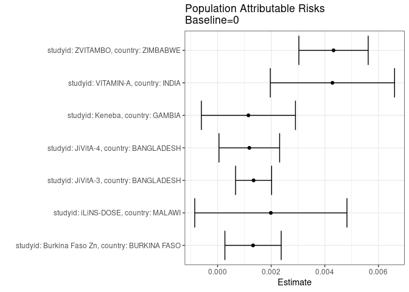

## Results Table

### Parameter: TSM

| studyid | country | intervention_level | baseline_level | estimate | ci_lower | ci_upper |
| --- | --- | --- | --- | --- | --- | --- |
| Burkina Faso Zn | BURKINA FASO | 0 | NA | 0.0041201 | 0.0025049 | 0.0057354 |
| Burkina Faso Zn | BURKINA FASO | 1 | NA | 0.0123579 | 0.0057589 | 0.0189568 |
| iLiNS-DOSE | MALAWI | 0 | NA | 0.0657822 | 0.0543554 | 0.0772090 |
| iLiNS-DOSE | MALAWI | 1 | NA | 0.1230769 | 0.0431899 | 0.2029640 |
| JiVitA-3 | BANGLADESH | 0 | NA | 0.0112614 | 0.0097691 | 0.0127538 |
| JiVitA-3 | BANGLADESH | 1 | NA | 0.0319015 | 0.0216870 | 0.0421160 |
| JiVitA-4 | BANGLADESH | 0 | NA | 0.0078352 | 0.0053217 | 0.0103487 |
| JiVitA-4 | BANGLADESH | 1 | NA | 0.0230707 | 0.0093762 | 0.0367652 |
| Keneba | GAMBIA | 0 | NA | 0.0148380 | 0.0101545 | 0.0195214 |
| Keneba | GAMBIA | 1 | NA | 0.0314136 | 0.0066714 | 0.0561558 |
| VITAMIN-A | INDIA | 0 | NA | 0.0042907 | 0.0019646 | 0.0066167 |
| VITAMIN-A | INDIA | 1 | NA | 0.0309504 | 0.0166846 | 0.0452162 |
| ZVITAMBO | ZIMBABWE | 0 | NA | 0.0301364 | 0.0269730 | 0.0332997 |
| ZVITAMBO | ZIMBABWE | 1 | NA | 0.2011741 | 0.1639638 | 0.2383844 |

### Parameter: E(Y)

| studyid | country | intervention_level | baseline_level | estimate | ci_lower | ci_upper |
| --- | --- | --- | --- | --- | --- | --- |
| Burkina Faso Zn | BURKINA FASO | NA | NA | 0.0054439 | 0.0037399 | 0.0071479 |
| iLiNS-DOSE | MALAWI | NA | NA | 0.0677695 | 0.0563864 | 0.0791525 |
| JiVitA-3 | BANGLADESH | NA | NA | 0.0126052 | 0.0110619 | 0.0141486 |
| JiVitA-4 | BANGLADESH | NA | NA | 0.0090190 | 0.0064698 | 0.0115681 |
| Keneba | GAMBIA | NA | NA | 0.0159884 | 0.0113013 | 0.0206755 |
| VITAMIN-A | INDIA | NA | NA | 0.0085754 | 0.0055692 | 0.0115815 |
| ZVITAMBO | ZIMBABWE | NA | NA | 0.0344621 | 0.0311558 | 0.0377684 |

### Parameter: RR

| studyid | country | intervention_level | baseline_level | estimate | ci_lower | ci_upper |
| --- | --- | --- | --- | --- | --- | --- |
| Burkina Faso Zn | BURKINA FASO | 0 | 0 | 1.000000 | 1.0000000 | 1.000000 |
| Burkina Faso Zn | BURKINA FASO | 1 | 0 | 2.999371 | 1.5466615 | 5.816547 |
| iLiNS-DOSE | MALAWI | 0 | 0 | 1.000000 | 1.0000000 | 1.000000 |
| iLiNS-DOSE | MALAWI | 1 | 0 | 1.870976 | 0.9555545 | 3.663372 |
| JiVitA-3 | BANGLADESH | 0 | 0 | 1.000000 | 1.0000000 | 1.000000 |
| JiVitA-3 | BANGLADESH | 1 | 0 | 2.832810 | 2.0037341 | 4.004929 |
| JiVitA-4 | BANGLADESH | 0 | 0 | 1.000000 | 1.0000000 | 1.000000 |
| JiVitA-4 | BANGLADESH | 1 | 0 | 2.944495 | 1.4954296 | 5.797699 |
| Keneba | GAMBIA | 0 | 0 | 1.000000 | 1.0000000 | 1.000000 |
| Keneba | GAMBIA | 1 | 0 | 2.117112 | 0.9062270 | 4.945961 |
| VITAMIN-A | INDIA | 0 | 0 | 1.000000 | 1.0000000 | 1.000000 |
| VITAMIN-A | INDIA | 1 | 0 | 7.213449 | 3.5413160 | 14.693366 |
| ZVITAMBO | ZIMBABWE | 0 | 0 | 1.000000 | 1.0000000 | 1.000000 |
| ZVITAMBO | ZIMBABWE | 1 | 0 | 6.675457 | 5.3965290 | 8.257480 |

### Parameter: PAR

| studyid | country | intervention_level | baseline_level | estimate | ci_lower | ci_upper |
| --- | --- | --- | --- | --- | --- | --- |
| Burkina Faso Zn | BURKINA FASO | 0 | NA | 0.0013237 | 0.0002736 | 0.0023739 |
| iLiNS-DOSE | MALAWI | 0 | NA | 0.0019873 | -0.0008518 | 0.0048264 |
| JiVitA-3 | BANGLADESH | 0 | NA | 0.0013438 | 0.0006713 | 0.0020164 |
| JiVitA-4 | BANGLADESH | 0 | NA | 0.0011838 | 0.0000525 | 0.0023150 |
| Keneba | GAMBIA | 0 | NA | 0.0011504 | -0.0006044 | 0.0029052 |
| VITAMIN-A | INDIA | 0 | NA | 0.0042847 | 0.0019674 | 0.0066020 |
| ZVITAMBO | ZIMBABWE | 0 | NA | 0.0043257 | 0.0030329 | 0.0056186 |

### Parameter: PAF

| studyid | country | intervention_level | baseline_level | estimate | ci_lower | ci_upper |
| --- | --- | --- | --- | --- | --- | --- |
| Burkina Faso Zn | BURKINA FASO | 0 | NA | 0.2431602 | 0.0429947 | 0.4014594 |
| iLiNS-DOSE | MALAWI | 0 | NA | 0.0293241 | -0.0132259 | 0.0700872 |
| JiVitA-3 | BANGLADESH | 0 | NA | 0.1066071 | 0.0540332 | 0.1562592 |
| JiVitA-4 | BANGLADESH | 0 | NA | 0.1312520 | 0.0008931 | 0.2446023 |
| Keneba | GAMBIA | 0 | NA | 0.0719534 | -0.0423229 | 0.1737010 |
| VITAMIN-A | INDIA | 0 | NA | 0.4996541 | 0.2442583 | 0.6687413 |
| ZVITAMBO | ZIMBABWE | 0 | NA | 0.1255216 | 0.0890307 | 0.1605508 |